# AFT dgm examples

```r
# Set options
knitr::opts_chunk$set(
  echo = TRUE,
  warning = FALSE,
  message = FALSE,
  fig.align = 'center',
  fig.retina = 2
)

# Load required libraries
library(survival)
library(knitr)
library(kableExtra)
library(ggplot2)
library(dplyr)
library(tidyr)
library(purrr)
library(broom)
library(gridExtra)
library(gt)

library(weightedsurv)

library(forestsearch)
library(doFuture)
library(doRNG)
# Set theme for plots
theme_set(theme_minimal(base_size = 12))

# library(devtools)
# install_github("larry-leon/forestsearch")
# install_github("larry-leon/weightedsurv")

library(forestsearch)
```

# Introduction

## Study Overview

This document presents a comprehensive simulation study using the German Breast Cancer Study Group (GBSG) dataset. We demonstrate:

1. **Flexible subgroup definition** using quantile-based cutpoints
2. **Calibration of interaction effects** to achieve target hazard ratios
3. **Sensitivity analysis** of treatment-subgroup interactions
4. **Forest search methodology** for subgroup identification
5. **Bootstrap inference** for subgroup stability

## Data Description

The GBSG dataset contains information from a randomized clinical trial of adjuvant therapy for node-positive breast cancer patients.

```r
# Load GBSG data
data(cancer)

# Dataset summary
data_summary <- data.frame(
  Variable = names(gbsg),
  Type = sapply(gbsg, class),
  Missing = sapply(gbsg, function(x) sum(is.na(x))),
  Unique = sapply(gbsg, function(x) length(unique(x))),
  Description = c(
    "Patient ID",
    "Hormonal therapy (0=no, 1=yes)",
    "Age in years",
    "Menopausal status (0=pre, 1=post)",
    "Tumor size (mm)",
    "Tumor grade (1,2,3)",
    "Number of positive nodes",
    "Progesterone receptor (fmol/l)",
    "Estrogen receptor (fmol/l)",
    "Recurrence-free survival time (days)",
    "Censoring status (0=censored, 1=event)"
  )
)

kable(data_summary, row.names = FALSE) %>%
  kable_styling(bootstrap_options = c("striped", "hover", "condensed"))
```

[output not shown]

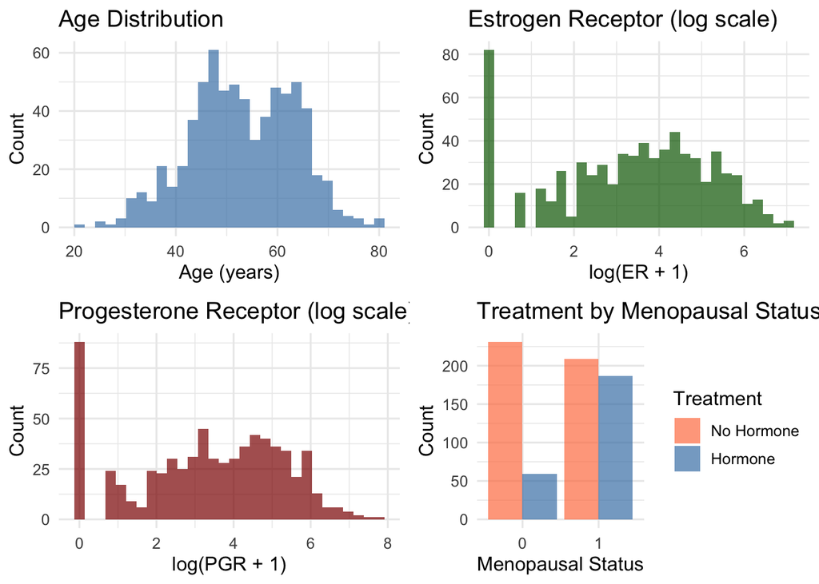

```r
# Create distribution plots
p1 <- ggplot(gbsg, aes(x = age)) +
  geom_histogram(bins = 30, fill = "steelblue", alpha = 0.7) +
  labs(title = "Age Distribution", x = "Age (years)", y = "Count")

p2 <- ggplot(gbsg, aes(x = log1p(er))) +
  geom_histogram(bins = 30, fill = "darkgreen", alpha = 0.7) +
  labs(title = "Estrogen Receptor (log scale)", x = "log(ER + 1)", y = "Count")

p3 <- ggplot(gbsg, aes(x = log1p(pgr))) +
  geom_histogram(bins = 30, fill = "darkred", alpha = 0.7) +
  labs(title = "Progesterone Receptor (log scale)", x = "log(PGR + 1)", y = "Count")

p4 <- ggplot(gbsg, aes(x = factor(meno), fill = factor(hormon))) +
  geom_bar(position = "dodge", alpha = 0.7) +
  scale_fill_manual(values = c("0" = "coral", "1" = "steelblue"),
                    labels = c("No Hormone", "Hormone")) +
  labs(title = "Treatment by Menopausal Status",
       x = "Menopausal Status", y = "Count", fill = "Treatment")

grid.arrange(p1, p2, p3, p4, ncol = 2)
```

# AFT Data Generating Mechanism

## Model Specification

We use an Accelerated Failure Time (AFT) model with Weibull distribution:

$$\log(T) = \mu + \gamma' X + \sigma
\epsilon$$

where:

- $T$ is the survival time
- $\mu$ is the intercept
- $\gamma$ contains the covariate effects including treatment and interaction
- $X$ includes covariates and treatment×subgroup interaction
- $\sigma$ is the scale parameter
- $\epsilon$ follows an extreme value distribution

## Subgroup Definition

We define a subgroup based on two characteristics:

1. **Low estrogen receptor (ER)**: ER ≤ 25th percentile
2. **Pre-menopausal status**: meno = 0

```r
# Calculate ER quantile cutpoint
er_quantile <- 0.2612616  # Approximately 25th percentile
er_cutpoint <- quantile(gbsg$er, probs = er_quantile)

# Create subgroup indicator
gbsg$subgroup <- with(gbsg, (er <= er_cutpoint) & (meno == 0))

# Subgroup summary
subgroup_summary <- data.frame(
  Criterion = c("ER ≤ 25th percentile", "Pre-menopausal", "Both conditions"),
  N = c(sum(gbsg$er <= er_cutpoint),
        sum(gbsg$meno == 0),
        sum(gbsg$subgroup)),
  Proportion = c(mean(gbsg$er <= er_cutpoint),
                 mean(gbsg$meno == 0),
                 mean(gbsg$subgroup))
)

kable(subgroup_summary,
      col.names = c("Criterion", "N", "Proportion"),
      digits = 3) %>%
  kable_styling(bootstrap_options = c("striped", "hover"))
```

| Criterion | N | Proportion |
| --- | --- | --- |
| ER ≤ 25th percentile | 179 | 0.261 |
| Pre-menopausal | 290 | 0.423 |
| Both conditions | 84 | 0.122 |

# Calibrating Interaction Effects

## Finding k_inter for Target Hazard Ratio

We calibrate the interaction parameter `k_inter` to achieve specific hazard ratios in the harm subgroup.

```r
# Transform time to months
df_gbsg <- gbsg
df_gbsg$tte <- with(gbsg, rfstime/30.4375)

# Find k_inter for HR_harm = 2.0
result <- forestsearch::find_k_inter_for_target_hr(
  target_hr_harm = 2.0,
  data = gbsg,
  outcome_var = "rfstime",
  event_var = "status",
  treatment_var = "hormon",
  continuous_vars = c("age", "er", "pgr"),
  factor_vars = c("meno", "grade"),
  subgroup_vars = c("er", "meno"),
  subgroup_cuts = list(
    er = list(type = "quantile", value = er_quantile),
    meno = 0
  ),
  k_treat = 1.0,
  verbose = FALSE
)

calibration_results <- data.frame(
  Target_HR = 2.0,
  Optimal_k_inter = round(result$k_inter, 4),
  Achieved_HR = round(result$achieved_hr_harm, 4),
  Error = round(result$error, 6)
)

kable(calibration_results,
      col.names = c("Target HR", "Optimal k_inter", "Achieved HR", "Error")) %>%
  kable_styling(bootstrap_options = c("striped", "hover"))
```

|  | Target HR | Optimal k_inter | Achieved HR | Error |
| --- | --- | --- | --- | --- |
| treat | 2 | 1.3009 | 2.0002 | 0.000162 |

## Sensitivity Analysis

We examine how `k_inter` affects the hazard ratios across different subgroups.

```r
# Define base parameters
base_params <- list(
  data = df_gbsg,
  continuous_vars = c("age", "size", "nodes", "pgr", "er"),
  factor_vars = c("meno", "grade"),
  outcome_var = "tte",
  event_var = "status",
  treatment_var = "hormon",
  subgroup_vars = c("er", "meno"),
  subgroup_cuts = list(
    er = list(type = "quantile", value = er_quantile),
    meno = 0
  ),
  k_treat = 1.0,
  n_super = 5000
)

# Run sensitivity analysis
sensitivity_results <- do.call(sensitivity_analysis_k_inter, c(
  list(
    k_inter_range = c(-1.5, 1.5),
    n_points = 11,
    model = "alt"
  ),
  base_params
))
```

```
## Running sensitivity analysis...
##   |                                                                              |                                                                      |   0%  |                                                                              |======                                                   …
```

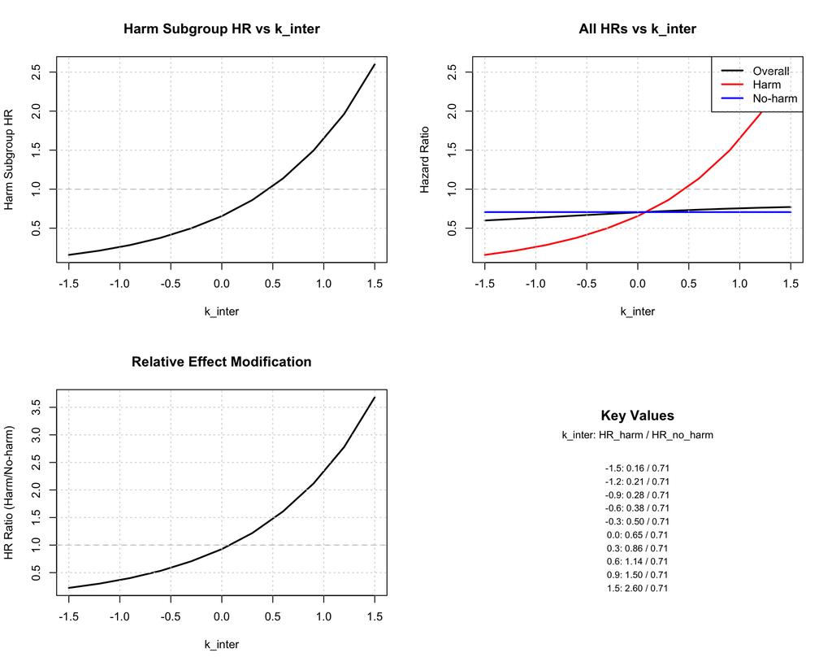

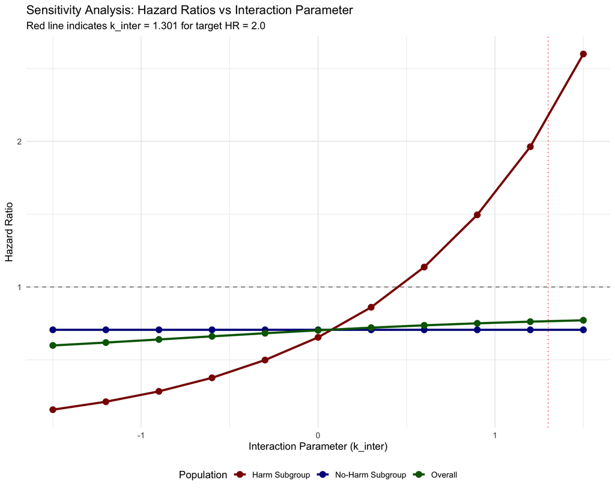

```r
# Create long format for plotting
sens_long <- sensitivity_results %>%
  select(k_inter, hr_harm, hr_no_harm, hr_overall) %>%
  pivot_longer(cols = -k_inter, names_to = "Group", values_to = "HR") %>%
  mutate(Group = case_when(
    Group == "hr_harm" ~ "Harm Subgroup",
    Group == "hr_no_harm" ~ "No-Harm Subgroup",
    Group == "hr_overall" ~ "Overall"
  ))

# Plot sensitivity
ggplot(sens_long, aes(x = k_inter, y = HR, color = Group)) +
  geom_line(size = 1.2) +
  geom_point(size = 3) +
  geom_hline(yintercept = 1, linetype = "dashed", alpha = 0.5) +
  geom_vline(xintercept = result$k_inter, linetype = "dotted",
             color = "red", alpha = 0.7) +
  scale_color_manual(values = c("Harm Subgroup" = "darkred",
                               "No-Harm Subgroup" = "darkblue",
                               "Overall" = "darkgreen")) +
  labs(title = "Sensitivity Analysis: Hazard Ratios vs Interaction Parameter",
       subtitle = paste("Red line indicates k_inter =", round(result$k_inter, 3),
                       "for target HR = 2.0"),
       x = "Interaction Parameter (k_inter)",
       y = "Hazard Ratio",
       color = "Population") +
  theme_minimal(base_size = 12) +
  theme(legend.position = "bottom")
```

# Simulation Studies

## Null Scenario (No Interaction)

```r
# Generate DGM with no interaction
dgm_null <- generate_aft_dgm_flex(
  data = df_gbsg,
  n_super = 5000,
  continuous_vars = c("age", "er", "pgr"),
  factor_vars = c("meno", "grade"),
  outcome_var = "tte",
  event_var = "status",
  treatment_var = "hormon",
  subgroup_vars = c("er", "meno"),
  subgroup_cuts = list(
    er = list(type = "quantile", value = er_quantile),
    meno = 0
  ),
  model = "null",
  k_inter = 0.0,
  verbose = FALSE
)

# Simulate data
set.seed(123)
draw_null <- simulate_from_dgm(
  dgm = dgm_null,
  n = 700,
  rand_ratio = 1,
  draw_treatment = TRUE,
  max_follow = Inf,
  seed = 123
)

# Summary statistics
null_summary <- data.frame(
  Metric = c("Sample Size", "Event Rate", "Treatment Allocation",
             "Subgroup Size", "Subgroup Proportion"),
  Value = c(nrow(draw_null),
            mean(draw_null$event_sim),
            mean(draw_null$treat_sim),
            sum(draw_null$flag_harm),
            mean(draw_null$flag_harm))
)

kable(null_summary, digits = 3) %>%
  kable_styling(bootstrap_options = c("striped", "hover"))
```

| Metric | Value |
| --- | --- |
| Sample Size | 700.000 |
| Event Rate | 0.403 |
| Treatment Allocation | 0.500 |
| Subgroup Size | 0.000 |
| Subgroup Proportion | 0.000 |

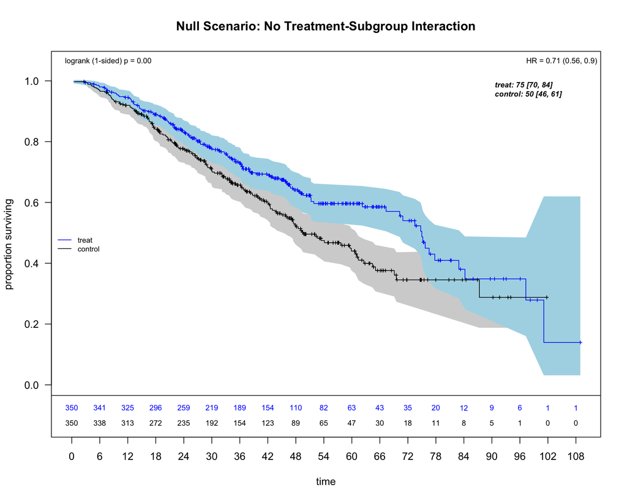

```r
# Prepare data for KM plot
dfcount_null <- df_counting(
  df = draw_null,
  tte.name = "y_sim",
  event.name = "event_sim",
  treat.name = "treat_sim"
)

# Create KM plot
plot_weighted_km(dfcount_null, conf.int = TRUE, show.logrank = TRUE, ymax = 1.05)
title(main = "Null Scenario: No Treatment-Subgroup Interaction")
```

## Alternative Scenario (With Interaction)

```r
df_gbsg$erlog <- log(df_gbsg$er+1)

# Example: Spline treatment effect on ER with subgroup interaction on meno
# dgm_spline <- generate_aft_dgm_flex(
#   data = df_gbsg,
#   continuous_vars = c("age", "size", "pgr","erlog"),
#   factor_vars = c("meno", "grade"),
#   outcome_var = "tte",
#   event_var = "status",
#   treatment_var = "hormon",
#   subgroup_vars = "meno",  # Subgroup on meno
#   subgroup_cuts = list(meno = 0),
#   model = "alt",
#   spline_spec = list(
#     var = "z_erlog",  # Use original variable name (or "z_er" if transformed)
#     knot = log(10),
#     zeta = log(20),
#     log_hrs = log(c(0.9, 0.7, 0.6))  # HR varies with ER
#   ),
#   k_inter = 0.0,  # Amplify meno subgroup effect
#   verbose = TRUE
# )


dgm_spline <- generate_aft_dgm_flex(
  data = df_gbsg,
  continuous_vars = c("age", "size", "pgr","erlog"),
  factor_vars = c("meno", "grade"),
  set_beta_spec = list(set_var = c("z_meno"), beta_var = -log(4)),
  outcome_var = "tte",
  event_var = "status",
  treatment_var = "hormon",
  subgroup_vars = NULL,
  subgroup_cuts = NULL,
  model = "alt",
  spline_spec = list(
    var = "z_erlog",  # Use original variable name (or "z_er" if transformed)
    knot = log(5),
    zeta = log(20),
    log_hrs = log(c(1.5, 0.9, 0.6))  # HR varies with ER
  ),
  k_inter = 0.0,  # Amplify meno subgroup effect
  verbose = TRUE
)
```

```
##
## Added 5 unprocessed variables: pid, nodes, er, rfstime, subgroup
##
## === Spline Constraint Applied ===
## Target log(HR) at z_erlog = 0: 0.405
## Target log(HR) at z_erlog = knot ( 1.609438 ): -0.105
## Target log(HR) at z_erlog = zeta ( 2.995732 ): -0.511
## k_treat multiplier: 1
##
## === Model Parameters (AFT with Spline, log(T)) ===
## Intercept (mu): 4.285
## Scale (tau): 0.739
## Spline variable: z_erlog
##   Knot: 1.609
##   Zeta: 2.996
## Treatment effect at z_erlog = 0: -0.3
## Treatment slope before knot: 0.235
## Treatment slope change after knot: -0.018
##
## Overall subgroup in super-population (all conditions met):
##   Proportion: 0
##
## === Hazard Ratios (super popln) ===
## Overall HR: 0.652
## Causal AHR: 0.546
```

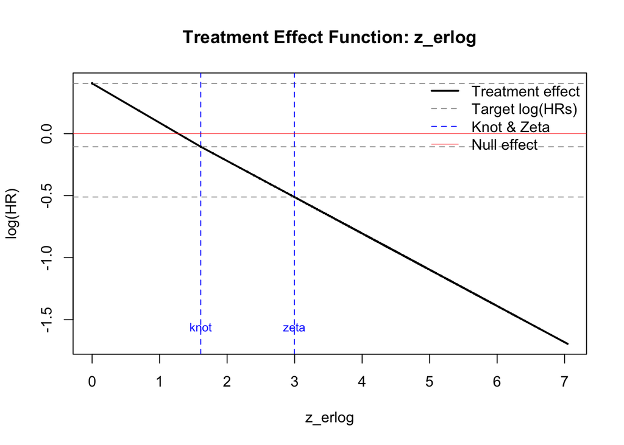

```r
# Plot the spline effect
plot_spline_treatment_effect(dgm_spline)
```

```r
dgm_spline$model_params$b0
```

```
##           treat           z_age          z_size           z_pgr         z_erlog
##     0.405465108    -0.003814137     0.016091887    -0.002118519     0.153080452
##          z_meno       z_grade_1       z_grade_2   z_erlog_treat       z_erlog_k
##    -1.386294361    -0.815034884    -0.122957515    -0.317393806    -0.216194371
## z_erlog_k_treat
##     0.024912555
```

```r
dgm_spline$model_params$censoring$gamma
```

```
##     X_censtreat     X_censz_age    X_censz_size     X_censz_pgr   X_censz_erlog
##    0.0652402418    0.0010567956   -0.0005849826   -0.0001936859    0.0057291561
##    X_censz_meno X_censz_grade_1 X_censz_grade_2
##   -0.0057289844    0.0593628963    0.1056833750
```

```r
names(dgm_spline$df_super)
```

```
##  [1] "id"              "y"               "treat"           "event"
##  [5] "z_age"           "z_size"          "z_pgr"           "z_erlog"
##  [9] "z_meno"          "z_grade_1"       "z_grade_2"       "pid"
## [13] "nodes"           "er"              "rfstime"         "subgroup"
## [17] "flag_harm"       "z_erlog_treat"   "z_erlog_k"       "z_erlog_k_treat"
## [21] "lin_pred_1"      "lin_pred_0"      "lin_pred_obs"    "theta_0"
## [25] "theta_1"         "loghr_po"        "lin_pred_cens_1" "lin_pred_cens_0"
```

```
##
## === Z Variable Summary ===
## Range: 0 7
## Quantiles (75%, 80%, 90%): 4.77 5.03 5.61
## Prediction grid: 23 points from 0 to 5.5
##
## === Primary Cox Model ===
## Treatment log(HR): -0.368
## Treatment HR: 0.692
##
## === Spline Model ===
## Number of parameters: 7
## Treatment main effect: 0.69
```

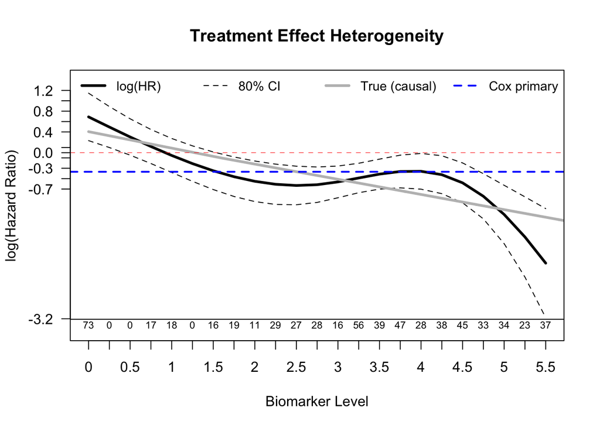

```r
# Simulate data
set.seed(123)
draw_spline <- simulate_from_dgm(
  dgm = dgm_spline,
  n = 700,
  rand_ratio = 1,
  draw_treatment = TRUE,
  max_follow = Inf,
  seed = 123
)

result <- cox_cs_fit(
  df = draw_spline, tte_name = "y_sim", event_name ="event_sim", treat_name = "treat_sim",
  truebeta_name = "loghr_po",
  z_name = "z_erlog", z_by = 0.25, z_window = 0.125,
  alpha = 0.20,
  plot_params = list(
    xlab = "Biomarker Level",
    main_title = "Treatment Effect Heterogeneity"
  )
)
```

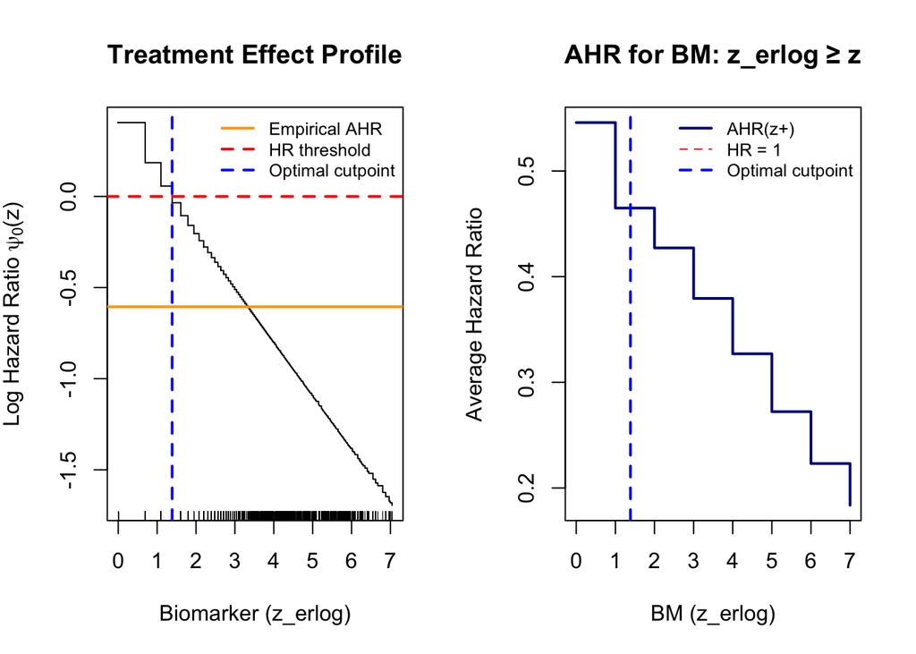

```r
# dfp <- data.table::setorder(draw_spline,z_erlog)
# with(dfp, plot(z_erlog, loghr_po, type="l", lty=1))

# Specify critical HR threshold
results <- plot_subgroup_effects(dgm_spline$df_super, z ="z_erlog", hrz_crit = 0)
```

```r
# Find "k" to achieve target HR in subgroup
result <- forestsearch::find_k_inter_for_target_hr(
  target_hr_harm = 2.0,
  data = df_gbsg,
  outcome_var = "rfstime",
  event_var = "status",
  treatment_var = "hormon",
  continuous_vars = c("age", "er", "pgr"),
  factor_vars = c("meno", "grade"),
  subgroup_vars = c("er", "meno"),
  subgroup_cuts = list(
    er = list(type = "quantile", value = er_quantile),
    meno = 0
  ),
  k_treat = 1.0,
  verbose = FALSE
)


# Generate DGM with calibrated interaction
dgm_alt <- generate_aft_dgm_flex(
  data = df_gbsg,
  n_super = 5000,
  continuous_vars = c("age", "er", "pgr"),
  factor_vars = c("meno", "grade"),
  outcome_var = "tte",
  event_var = "status",
  treatment_var = "hormon",
  subgroup_vars = c("er", "meno"),
  subgroup_cuts = list(
    er = list(type = "quantile", value = er_quantile),
    meno = 0
  ),
  model = "alt",
  k_inter = result$k_inter,
  verbose = FALSE
)

# Simulate data
set.seed(123)
draw_alt <- simulate_from_dgm(
  dgm = dgm_alt,
  n = 700,
  rand_ratio = 1,
  max_follow = Inf,
  seed = 123
)

# Summary statistics
alt_summary <- data.frame(
  Metric = c("Sample Size", "Event Rate", "Treatment Allocation",
             "Subgroup Size", "Subgroup Proportion"),
  Value = c(nrow(draw_alt),
            mean(draw_alt$event_sim),
            mean(draw_alt$treat_sim),
            sum(draw_alt$flag_harm),
            mean(draw_alt$flag_harm))
)

kable(alt_summary, digits = 3) %>%
  kable_styling(bootstrap_options = c("striped", "hover"))
```

| Metric | Value |
| --- | --- |
| Sample Size | 700.000 |
| Event Rate | 0.419 |
| Treatment Allocation | 0.500 |
| Subgroup Size | 87.000 |
| Subgroup Proportion | 0.124 |

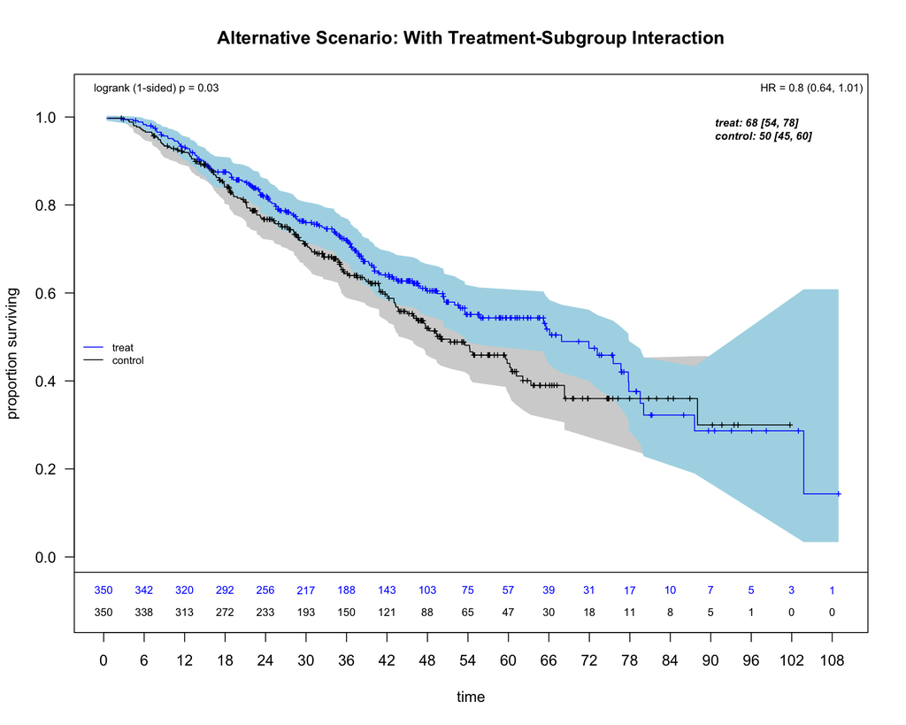

```r
# Prepare data for KM plot
dfcount_alt <- df_counting(
  df = draw_alt,
  tte.name = "y_sim",
  event.name = "event_sim",
  treat.name = "treat_sim"
)

# Create KM plot
par(mfrow=c(1,1))
plot_weighted_km(dfcount_alt, conf.int = TRUE, show.logrank = TRUE, ymax = 1.05)
title(main = "Alternative Scenario: With Treatment-Subgroup Interaction")
```

# Forest Search Analysis

## Methodology

Forest search is a systematic approach to identify subgroups with differential treatment effects using:

1. **Recursive partitioning** to explore covariate space
2. **Hazard ratio thresholds** to identify meaningful effects
3. **Consistency criteria** to ensure stability
4. **Bootstrap inference** for uncertainty quantification

```r
# Define confounders for forest search
confounders.name <- c("z_age", "z_er", "z_pgr", "z_meno",
                      "z_grade_1", "z_grade_2", "size", "nodes")

# Setup parallel processing
library(doFuture)
library(doRNG)

registerDoFuture()
registerDoRNG()

df_null <- as.data.frame(draw_null)

system.time({fs <- forestsearch(df_null,  confounders.name=confounders.name,
                                outcome.name = "y_sim", treat.name = "treat_sim", event.name = "event_sim", id.name = "id",
                                potentialOutcome.name = "loghr_po", flag_harm.name = "flag_harm",
                                hr.threshold = 1.25, hr.consistency = 1.0, pconsistency.threshold = 0.90,
                                sg_focus = "hrMaxSG",
                                showten_subgroups = FALSE, details=TRUE,
                                conf_force = c("z_age <= 65", "z_er <= 0", "z_er <= 1", "z_er <= 2","z_er <= 5"),
                                cut_type = "default", use_grf = TRUE, plot.grf = TRUE, use_lasso = TRUE,
                                maxk = 1, n.min = 60, d0.min = 12, d1.min = 12,
                                plot.sg = TRUE, by.risk = 120,
                                parallel_args = list(plan="callr", workers = 12, show_message = TRUE)
)
})
```

```
## GRF stage for cut selection with dmin,tau= 12 0.6
## tau, maxdepth = 52.39242 2
##    leaf.node control.mean control.size control.se depth
## 1          2        -3.37       692.00       1.22     1
## 11         4        -5.21       457.00       1.49     2
## 3          6        10.01        68.00       3.67     2
## 4          7        -4.54       154.00       2.58     2
##
## Selected subgroup:
##   leaf.node control.mean control.size control.se depth
## 3         6        10.01        68.00       3.67     2
##
## GRF subgroup found
## Terminating node at max.diff (sg.harm.id):
## [1] "size <= 25"
##
## All splits:
## [1] "size <= 80" "nodes <= 5" "size <= 45" "size <= 25"
## # of continuous/categorical characteristics 5 3
## Continuous characteristics: z_age z_er z_pgr size nodes
## Categorical characteristics: z_meno z_grade_1 z_grade_2
## ## Prior to lasso: z_age z_er z_pgr size nodes
## #### Lasso selection results
## 8 x 1 sparse Matrix of class "dgCMatrix"
##                      s0
## z_age      .
## z_er      -0.0002609910
## z_pgr     -0.0011806604
## z_meno     0.1142905934
## z_grade_1 -0.6624164689
## z_grade_2  .
## size       0.0007465114
## nodes      .
## Cox-LASSO selected: z_er z_pgr z_meno z_grade_1 size
## Cox-LASSO not selected: z_age z_grade_2 nodes
## ### End Lasso selection
## ## After lasso: z_er z_pgr size
## Default cuts included from Lasso: z_er <= mean(z_er) z_er <= median(z_er) z_er <= qlow(z_er) z_er <= qhigh(z_er) z_pgr <= mean(z_pgr) z_pgr <= median(z_pgr) z_pgr <= qlow(z_pgr) z_pgr <= qhigh(z_pgr) size <= mean(size) size <= median(size) size <= qlow(size) size <= qhigh(size)
## Categorical after Lasso: z_meno z_grade_1
## Factors per GRF: size <= 80 nodes <= 5 size <= 45 size <= 25
```

[output cut: 33 more lines]

```
## 20     size <= 35    q20  0.0372
## 17   z_pgr <= 135    q17  0.0363
## 4      size <= 25     q4  0.0339
## 10   z_er <= 97.1    q10  0.0335
## 13    z_er <= 117    q13  0.0328
## 6       z_er <= 0     q6  0.0207
## 5     z_age <= 65     q5  0.0176
## 7       z_er <= 1     q7  0.0156
## 8       z_er <= 2     q8  0.0138
## 22      z_grade_1    q22  0.0089
## 1      size <= 80     q1  0.0000
## Number of possible configurations (<= maxk): maxk = 1 , # combinations = 44
## Events criteria: control >= 12 , treatment >= 12
## Subgroup search completed in 0 minutes
## NO subgroup candidates found
```

```
##    user  system elapsed
##   2.793   0.031   0.646
```

```r
plan("sequential")
```

```
## GRF stage for cut selection with dmin,tau= 12 0.6
## tau, maxdepth = 52.8205 2
##    leaf.node control.mean control.size control.se depth
## 1          2         3.44       124.00       3.27     1
## 2          3        -3.43       576.00       1.33     1
## 11         4        -4.38       302.00       1.88     2
## 21         5         9.60        68.00       3.80     2
## 4          7        -4.17       285.00       1.89     2
##
## Selected subgroup:
##    leaf.node control.mean control.size control.se depth
## 21         5          9.6         68.0        3.8     2
##
## GRF subgroup found
## Terminating node at max.diff (sg.harm.id):
## [1] "nodes <= 5"
##
## All splits:
## [1] "z_er <= 4"  "size <= 26" "nodes <= 5" "z_er <= 0"
## # of continuous/categorical characteristics 5 3
## Continuous characteristics: z_age z_er z_pgr size nodes
## Categorical characteristics: z_meno z_grade_1 z_grade_2
## ## Prior to lasso: z_age z_er z_pgr size nodes
## #### Lasso selection results
## 8 x 1 sparse Matrix of class "dgCMatrix"
##                      s0
## z_age     -0.0008522668
## z_er      -0.0003750320
## z_pgr     -0.0015055782
## z_meno     .
## z_grade_1 -0.7506140627
## z_grade_2 -0.0049440538
## size       0.0011962601
## nodes      .
## Cox-LASSO selected: z_age z_er z_pgr z_grade_1 z_grade_2 size
## Cox-LASSO not selected: z_meno nodes
## ### End Lasso selection
## ## After lasso: z_age z_er z_pgr size
## Default cuts included from Lasso: z_age <= mean(z_age) z_age <= median(z_age) z_age <= qlow(z_age) z_age <= qhigh(z_age) z_er <= mean(z_er) z_er <= median(z_er) z_er <= qlow(z_er) z_er <= qhigh(z_er) z_pgr <= mean(z_pgr) z_pgr <= median(z_pgr) z_pgr <= qlow(z_pgr) z_pgr <= qhigh(z_pgr) size <= me…
## Categorical after Lasso: z_grade_1 z_grade_2
```

[output cut: 44 more lines]

```
## 20   z_pgr <= 135    q20  0.0214
## 2      size <= 26     q2  0.0191
## 8       z_er <= 5     q8  0.0160
## 22     size <= 25    q22  0.0158
## 5     z_age <= 65     q5  0.0100
## 25      z_grade_1    q25  0.0036
## Number of possible configurations (<= maxk): maxk = 1 , # combinations = 52
## Events criteria: control >= 12 , treatment >= 12
## Subgroup search completed in 0 minutes
## Found 4 subgroup candidate(s)
## # of candidate subgroups (meeting all criteria) = 4
## # of unique initial candidates: 4
## # Restricting to top stop_Kgroups = 10
## # of candidates restricted to 'top K': 4
## Using parallel processing: callr with 120 workers
```

```
## Consistency met!
## # of splits = 1000
## **** Subgroup, % Consistency Met= {z_er <= 0} 0.9
## *** Not met: Subgroup, % Consistency = {z_er <= 1} 0.83
## *** Not met: Subgroup, % Consistency = {z_er <= 2} 0.76
## *** Not met: Subgroup, % Consistency = {z_er <= 4} 0.8
```

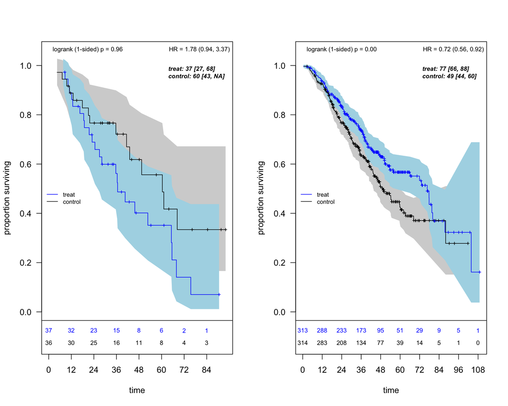

```
## *** Subgroup found: {z_er <= 0}
## % consistency criteria met= 0.9
## SG focus= hrMaxSG
## Subgroup Consistency Minutes= 0.2118333
## Subgroup found (FS) with sg_focus='hrMaxSG'
## Selected subgroup: {z_er <= 0}
## Minutes forestsearch overall = 0.22
```

```
##    user  system elapsed
##  11.834   1.295  13.350
```

```r
# Define confounders for forest search
confounders.name <- c("z_age", "z_er", "z_pgr", "z_meno",
                      "z_grade_1", "z_grade_2", "size", "nodes")

# Setup parallel processing
library(doFuture)
library(doRNG)

registerDoFuture()
registerDoRNG()

df_alt <- as.data.frame(draw_alt)

system.time({fs <- forestsearch(df_alt,  confounders.name=confounders.name,
                                outcome.name = "y_sim", treat.name = "treat_sim", event.name = "event_sim", id.name = "id",
                                hr.threshold = 1.25, hr.consistency = 1.0, pconsistency.threshold = 0.90,
                                potentialOutcome.name = "loghr_po", flag_harm.name = "flag_harm",
                                sg_focus = "hrMaxSG",
                                showten_subgroups = FALSE, details=TRUE,
                                conf_force = c("z_age <= 65", "z_er <= 0", "z_er <= 1", "z_er <= 2","z_er <= 5"),
                                cut_type = "default", use_grf = TRUE, plot.grf = TRUE, use_lasso = TRUE,
                                maxk = 1, n.min = 60, d0.min = 12, d1.min = 12,
                                plot.sg = TRUE, by.risk = 12,
                                parallel_args = list(plan="callr", workers = 120, show_message = TRUE)
)
})
```

```r
with(fs$df.est, table(flag_harm, treat.recommend))
```

```
##          treat.recommend
## flag_harm   0   1
##         0  28 585
##         1  45  42
```

```r
# Extract results
res_tabs <- sg_tables(fs, ndecimals = 3)

res_tabs$sg10_out
```

**Identified Subgroups**

Single-factor subgroups (maxk=1)

| Factor | N | Events | E₁ | HR | P<sub>cons</sub> |
| --- | --- | --- | --- | --- | --- |
| {z_er <= 0} | 73 | 39 | 24 | 1.784 | 0.900 |

**Search Configuration:** Single-factor candidates (L) = 52; Maximum combinations evaluated = 52; Search depth (maxk) = 1  
**Search Results:** Candidate subgroups found = 4; Maximum HR estimate = 1.78  
**Note:** E₁ = events in treatment arm; P<sub>cons</sub> = consistency proportion

```r
res_tabs$tab_estimates
```

**Treatment Effect Estimates**

Training data estimates

| Subgroup | n | n1 | events | m1 | m0 | RMST | HR (95% CI) | AHR(po) |
| --- | --- | --- | --- | --- | --- | --- | --- | --- |
| ITT | 700 (100.0%) | 350 (50.0%) | 293 (41.9%) | 67.9 | 50 | 4.4 | 0.80 (0.64, 1.01) | 0.72 |
| Questionable | 73 (10.4%) | 37 (50.7%) | 39 (53.4%) | 36.6 | 60.4 | -14 | 1.78 (0.94, 3.37) | 1.32 |
| Recommend | 627 (89.6%) | 313 (49.9%) | 254 (40.5%) | 76.7 | 49.3 | 7.5 | 0.72 (0.56, 0.92) | 0.67 |

```r
plan("sequential")
```

## Bootstrap Inference

```r
output_dir <- "results/"
save_results <- dir.exists(output_dir)

# patchhwork needed for a combined bootstrap plot (otherwise if not avaialable will not produce)
library(patchwork)

# Number of bootstrap samples
NB <- 1000

# Run bootstrap
t.start <- proc.time()[3]

fs_bc <- forestsearch_bootstrap_dofuture(
  fs.est = fs,
  nb_boots = NB,
  show_three = FALSE,
  details = TRUE)

plan("sequential")

t.min <- (proc.time()[3] - t.start) / 60

if (save_results) {
    filename <- file.path(output_dir,
                         paste0("sim_gbsg_example_B=",
                                format(NB),
                                ".RData"))
    save(fs_bc, fs, file = filename)
    cat("\nResults saved to:", filename, "\n")
}
```

```r
load("~/Documents/GitHub/forestsearch/vignettes/results/sim_gbsg_example_B=1000.RData")

summaries <- summarize_bootstrap_results(
      sgharm = fs$sg.harm,
      boot_results = fs_bc,
      create_plots = TRUE,
      est.scale = "hr"
    )
```

```
##
## ═══════════════════════════════════════════════════════════════
##            BOOTSTRAP ANALYSIS SUMMARY
## ═══════════════════════════════════════════════════════════════
##
## BOOTSTRAP SUCCESS METRICS:
## ─────────────────────────────────────────────────────────────
##   Total iterations:              1000
##   Successful subgroup ID:        616 (61.6%)
##   Failed to find subgroup:       384 (38.4%)
##
## TIMING ANALYSIS:
## ─────────────────────────────────────────────────────────────
## Overall:
##   Total bootstrap time:          16.73 minutes (0.28 hours)
##   Average per iteration:         0.02 min (1.0 sec)
##
## Per-iteration timing:
##   Mean:                          0.19 min (11.1 sec)
##   Median:                        0.18 min (11.0 sec)
##   Std Dev:                       0.11 minutes
##   Range:                         [0.01, 0.49] minutes
##   IQR:                           [0.10, 0.25] minutes
##
## ForestSearch timing (successful iterations only):
##   Iterations with FS:            1000 (100.0%)
##   Mean FS time:                  0.18 min (11.1 sec)
##   Median FS time:                0.18 min (11.0 sec)
##   Total FS time:                 184.91 minutes
##   FS time % of total:            1105.3%
##
## Overhead timing (Cox models, bias correction, etc.):
##   Mean overhead:                 0.00 min (0.0 sec)
##   Median overhead:               0.00 min (0.0 sec)
##   Total overhead:                0.20 minutes
##   Overhead % of total:           1.2%
##
## PERFORMANCE ASSESSMENT:
## ─────────────────────────────────────────────────────────────
##   Performance rating:            ✓✓✓ Excellent
##   Average iteration speed:       1.0 seconds
##
## ═══════════════════════════════════════════════════════════════
```

```r
sg_tab <- summaries$table

sg_tab
```

**Treatment Effect by Subgroup**

Bootstrap bias-corrected estimates (1000 iterations)

[output not shown]

<sup>1</sup> **Unadjusted HR**: Standard Cox regression hazard ratio with robust standard errors  
<sup>2</sup> **Bias-corrected HR**: Bootstrap-adjusted estimate using infinitesimal jacknife method (1000 iterations). Corrects for optimism in subgroup selection.  
*Note*: Med = Median survival time (months). RMST<sub>d</sub> = Restricted mean survival time difference. Subgroup identified in 61.6% of bootstrap samples.

```r
event_summary <- summarize_bootstrap_events(fs_bc, threshold = 12)
```

```
##
## === Bootstrap Event Count Summary ===
## Total bootstrap iterations: 1000
## Event threshold: <12 events
##
## ORIGINAL Subgroup H on BOOTSTRAP samples:
##   Control arm <12 events: 0 (0.0%)
##   Treatment arm <12 events: 0 (0.0%)
##   Either arm <12 events: 0 (0.0%)
##
## ORIGINAL Subgroup Hc on BOOTSTRAP samples:
##   Control arm <12 events: 0 (0.0%)
##   Treatment arm <12 events: 0 (0.0%)
##   Either arm <12 events: 0 (0.0%)
##
## NEW Subgroups found: 616 (61.6%)
##
## NEW Subgroup H* on ORIGINAL data:
##   Control arm <12 events: 0 (0.0% of successful)
##   Treatment arm <12 events: 0 (0.0% of successful)
##   Either arm <12 events: 0 (0.0% of successful)
##
## NEW Subgroup Hc* on ORIGINAL data:
##   Control arm <12 events: 0 (0.0% of successful)
##   Treatment arm <12 events: 0 (0.0% of successful)
##   Either arm <12 events: 0 (0.0% of successful)
```

```r
summaries$diagnostics_table_gt
```

**Bootstrap Diagnostics Summary**

Analysis of 1000 bootstrap iterations

| Category | Metric | Value |
| --- | --- | --- |
| Success Rate<sup>1</sup> | Total iterations | 1000 |
|  | Successful subgroup ID | 616 (61.6%) |
|  | Failed to find subgroup | 384 (38.4%) |
|  | Success rating | Acceptable ✓ |
| Subgroup H (Questionable) | Unadjusted estimate | 1.78 (0.94, 3.37) |
|  | Bias-corrected estimate | 1.27 (0.77, 2.10) |
|  | Bias correction impact<sup>2</sup> | 28.7% |
|  | CI width change<sup>3</sup> | 2.42 → 1.33 |
| Subgroup Hc (Recommend) | Unadjusted estimate | 0.72 (0.56, 0.92) |
|  | Bias-corrected estimate | 0.73 (0.50, 1.06) |
|  | Bias correction impact<sup>2</sup> | 1.7% |
|  | CI width change<sup>3</sup> | 0.36 → 0.55 |
| Bootstrap Quality: H | Valid iterations | 616 |
|  | Mean (SD) | 0.24 (0.34) |
|  | Coefficient of variation<sup>4</sup> | 140.8% |
|  | Skewness<sup>5</sup> | -0.12 |
| Bootstrap Quality: Hc | Valid iterations | 616 |
|  | Mean (SD) | -0.32 (0.22) |
|  | Coefficient of variation<sup>4</sup> | 68.3% |
|  | Skewness<sup>5</sup> | -0.07 |
| Search Performance | Mean max HR found | 2.14 (0.46) |
|  | Mean factors evaluated | 46.0 |
|  | Mean combinations tried | 46 |
|  | Proportion at maxk | — |

<sup>1</sup> **Success Rate**: Proportion of bootstrap samples where ForestSearch identified a valid subgroup  
<sup>2</sup> **Bias Correction Impact**: Percentage change from unadjusted to bias-corrected estimate  
<sup>3</sup> **CI Width Change**: Confidence interval width before → after bias correction  
<sup>4</sup> **Coefficient of Variation**: Standard deviation as % of mean (lower is better)  
<sup>5</sup> **Skewness**: Measure of asymmetry (0 = symmetric, |skew| < 1 is generally good)  
**Interpretation Guide:** ⚠ **Moderate stability**: Subgroup identification is somewhat unstable. Consider: • Increasing sample size • Adjusting consistency threshold • Examining failed iterations for patterns ⚠ **High variability**: Bootstrap estimates are imprecise (CV ≥ 25%). Consider increasing nb_boots or sample size.

```r
summaries$subgroup_summary$original_agreement
```

```
##                             Metric       Value
##                             <char>      <char>
## 1:      Total bootstrap iterations        1000
## 2:           Successful iterations         616
## 3: Failed iterations (no subgroup)         384
## 4:       Exact match with original  76 (12.3%)
## 5:         Different from original 540 (87.7%)
```

```r
#summaries$subgroup_summary$agreement

summaries$subgroup_summary$factor_presence
```

```
##   Rank Factor Count   Percent
## 4    1   z_er   403 65.422078
## 3    2  z_age    70 11.363636
## 1    3  nodes    53  8.603896
## 2    4   size    38  6.168831
## 6    5  z_pgr    30  4.870130
## 5    6 z_meno    22  3.571429
```

```r
summaries$subgroup_summary$factor_presence_specific
```

```
##    Rank Base_Factor Factor_Definition Count  Percent
## 65    1        z_er       {z_er <= 5}   101 16.39610
## 50    2        z_er       {z_er <= 0}    76 12.33766
## 51    3        z_er       {z_er <= 1}    65 10.55195
```

[figure not shown]

```r
summaries$plots$combined
```